# ¶ BIO_4303 : TP4 Foret aleatoire ¶

#### 1 Introduction

1.1 Objectifs

L’objectif de ce TD est d’apprendre à réaliser une prédiction avec la méthode des forêts aléatoires en utilisant les packages (i) randomForest (forêts aléatoires) et (ii) randomForestExplainer ( graphiques)

Le jeu de données utilisé est *heart.csv*.

Concernant la qualité de l’ajustement, nous utiliserons la fonction locale que nous avons décrite dans le TD sur la régression logistique multiple.

1.2 Rappels Les méthodes classiques de classification et régression par arbre (CART, C4.5) présentent une grande facilité d’utilisation avec peu de travail préliminaire sur les jeux de données ( transformation des variables par exemple) car ils peuvent traiter à la fois des variables qualitatives et quantitatives (cf. cours arbres). En revenche, ils présentent une instabilité aux données de fait de leur structure hiérarchique : Un changement mineur dans les données peut induire une modification de la structure de l’arbre et par conséquent une modification de la prédiction surtout si cette modification affecte les premiers noeuds de l’arbre.

En agrégeant des arbres de décisions, les forêts aléatoires permettent de remédier à ce problème. Ils augmentent en conséquence la robustesse en conservant tous les avantages des arbres. Le prix à payer est la lisibilité et l’interprétation des arbres.

Les forêts aléatoires permettent d’atteindre un pouvoir discriminant parmi les plus élevés de toutes les méthodes prédictives sans sur apprentissage qui se traduit par une meilleure généralisation tout en restant assez simple à paramètrer.

#### 2 Environnement

Pour réaliser notre objectif qui est d’apprendre à réaliser une prédiction avec la méthode des forêts aléatoires, nous utiliserons les packages : * ‘ggplot2’ * ‘caret’ * ‘pROC’ * ‘reshape2’ * ‘kableExtra’ * ‘randomForest’ * ‘randomForestExplainer’ * ‘colorRamps’

```r
Valid_ROC <- function(obs, pred, direction = 0, threshold  = NULL, graph = T)
{
  require(pROC)
  require(caret)
  if(!is.factor(obs)){obs <- factor(obs)} # si obs n'est pas un facteur alors obs est convertit avec factor
  lev        <- levels(obs)
  data_logit <- data.frame(obs = factor(obs), pred = pred) # création d'un dataframe qui contient 2 colonnes obs et pred les obs (observations réelles) et les preds(prédictions du modèle)
  data_roc   <- roc(obs,pred)  # On calcul la courbes roc avec obs et pred
  cir        <- ci(data_roc)  # ci Calcul les intervalles de confiance de l'AUC de la courbe roc

  # data_spec  contient les sensibilités, spécificités, seuils et l'indice Youden(sensibilité + spécificité - 1)
  data_spec  <- data.frame( sens    = data_roc$sensitivities ,
                            spec    = data_roc$specificities ,
                            thr     = data_roc$thresholds    ,
                            youden  = data_roc$sensitivities + data_roc$specificities - 1
                           )

  cir <- data.frame(roc = c(cir, youden = max(data_spec$youden) )) ; rownames(cir) <-c('AUC_lower','AUC','AUC_upper','youden')
  #-> si argument nulle alors calcul du seuil par la méthode de Youden
  if (is.null(threshold))
  {
    id       <- which.max(data_spec$youden) ; data_spec[id,] ;
    best_thr <- data_spec[id,3]
  }else{best_thr <- threshold}
  #-> binarisation
  if(direction == 0){dir_name <- lev[1] ; ndir_name <- lev[2] }else{dir_name = lev[2] ; ndir_name <- lev[1]}
  fac_roc    <- rep(dir_name,nrow(data_logit))
  id         <- which(pred >= best_thr) ; fac_roc[id] <- ndir_name ; fac_roc <- factor(fac_roc)
  conf_mat_1 <- confusionMatrix(fac_roc, obs)
  result     <- data.frame(Confusion = c(                 conf_mat_1$overall[1],
                                                          conf_mat_1$overall[3],
                                                          conf_mat_1$overall[4],
                                                          conf_mat_1$byClass[1],
                                                          conf_mat_1$byClass[2],
                                                          conf_mat_1$byClass[3],
                                                          conf_mat_1$byClass[4],
                                                          conf_mat_1$byClass[7],
                                                          Threshold  = best_thr
                                          )
                         )
  all_result <- list( result = result, Confusion = conf_mat_1$table, roc = cir)
  #--> graphique
  if(graph)
    {  data_gr    <- melt(data_spec, id.vars = 'thr')
       gr         <- ggplot(data = data_gr) + geom_line(aes(x = thr, y = value, color = variable )) +
       ylab('Probability') + xlab('threshold') + theme(legend.title = element_blank()) + geom_vline( xintercept = best_thr, color = '#0066CC')
      #--> courbe roc
      plot.roc(data_roc, print.auc=TRUE, print.thres=TRUE,col="#0066CC")
      all_result[['graph']] <- gr
  }
      return( all_result)
}
```

#### 3 Foret Aleatoire avec randomForest

```r
set.seed(457867)
#--> Données de déploiement
id_dep   <- createDataPartition(1:nrow(df1), p = 0.15, list = F)
XY_dep   <- df1[id_dep, ]   ; X_dep <- df1[  id_dep, 1:11] ; Y_dep <- df1[  id_dep,12]
#--> Données en entrainement et en test
XY        <- df1[- id_dep, ] ; X     <- df1[- id_dep, 1:11] ; Y    <- df1[- id_dep,12]
id_test   <- createDataPartition(1:nrow(XY), p = 0.3, list = F)
XY_test   <- XY[  id_test, ] ; X_test  <- XY[  id_test, 1:11] ; Y_test  <- XY[  id_test,12]
XY_train  <- XY[- id_test, ] ; X_train <- XY[- id_test, 1:11] ; Y_train <- XY[- id_test,12]
```

```r
set.seed(547213)
n_tree = 1000
rf1 <- randomForest(HeartDisease~., data = XY_train           ,
                    ntree       = n_tree                      ,
                    mtry        = floor(sqrt(ncol(X_train)))  ,
                    nodesize    = 1                           ,
                    replace     = T                           ,
                    importance  = T                           ,
                    keep.forest = T                           ,
                    proximity   = T                           ,
                    na.action   = na.omit                     ,
                    xtest       = X_test                      ,
                    ytest       = Y_test                      ,
                   )
```

##### 3.1 Résultats

Erreur out of bag

La fonction retourne une liste contenant différents résultats. Ils concernent d’une part, ceux obtenus sur les données d’entraînement (XY_train) et d’autre part, ceux obtenus sur le jeu de données test (X_test, Y_test).

Les résultats importants à analyser :

```r
idx <- 1:nrow(XY_train)
oob.time <- data.frame(Ind = paste0("ind_",idx)  ,OBB= rf1$oob.times)
head(oob.time)
```

```
##     Ind OBB
## 1 ind_1 358
## 2 ind_2 345
## 3 ind_3 358
## 4 ind_4 370
## 5 ind_5 351
## 6 ind_6 348
```

```r
tx_erreur_train <- rf1$err.rate
tx_erreur_test <- rf1$test$err.rate
head(tx_erreur_train)
```

```
##            OOB         0         1
## [1,] 0.2051282 0.2307692 0.1880342
## [2,] 0.2215190 0.2000000 0.2365591
## [3,] 0.2098446 0.2024540 0.2152466
## [4,] 0.2022472 0.1736842 0.2235294
## [5,] 0.2105263 0.2028986 0.2164179
## [6,] 0.1876248 0.1954545 0.1814947
```

On peut donc suivre à l’aide d’un graphique l’évolution des taux d’erreurs totaux en OOB sur le jeux d’entrainement (XY_train) mais aussi et surtout sur le jeux de données de test (X_test,Y_test). la comparaison des taux (entrainement et test) permettent de voir la qualité de l’ajustement et éventuellement modifier la paramétrage si besoin.

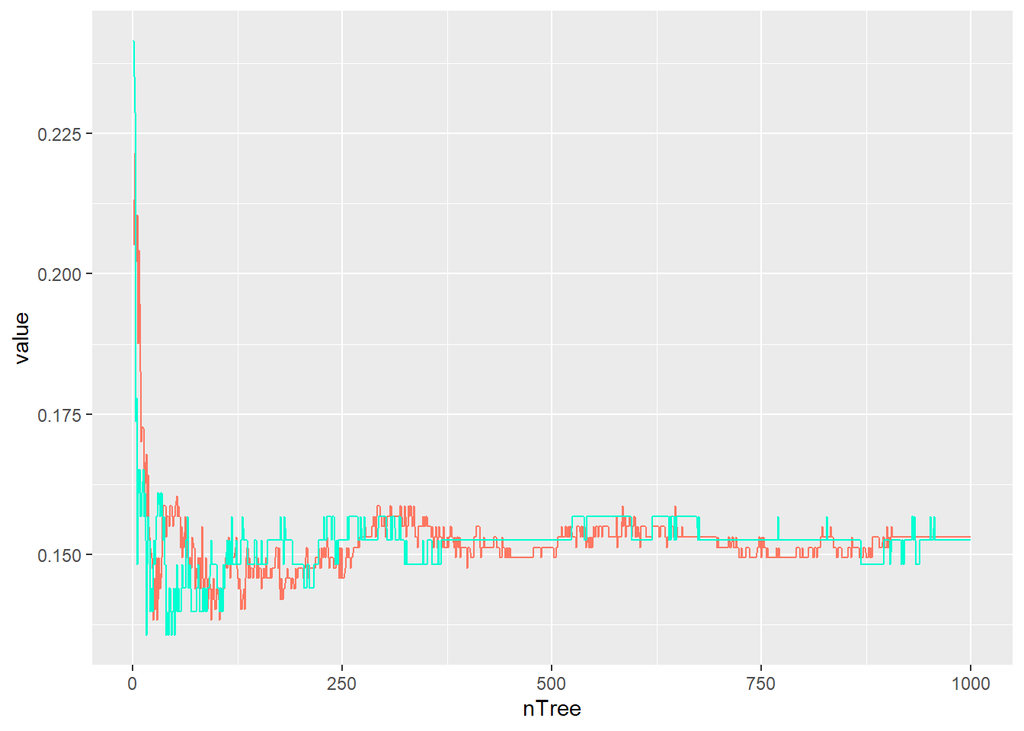

```r
OBB_train <- tx_erreur_train[,1]
Test <- tx_erreur_test[,1]
ntree <- 1:n_tree
tab_visualisation <- data.frame(OBB_train,Test)
ggplot(tab_visualisation, aes(x = ntree)) + geom_line(aes(y= OBB_train), color = "#FF7762") + geom_line(aes(y=Test), color ="#00FFD1") + xlab("nTree") + ylab("value") + theme(legend.position = "right")
```

##### 3.2 Qualité des Résultats

On peut calculer les courbes ROC en test à laide de la fonction Valid_Roc. Les résultats sont les suivants :

```r
head(rf1$test$votes,10)
```

```
##        0     1
## 3  0.932 0.068
## 9  0.245 0.755
## 11 0.998 0.002
## 13 0.999 0.001
## 15 0.989 0.011
## 20 0.661 0.339
## 26 0.999 0.001
## 31 0.441 0.559
## 32 0.944 0.056
## 34 0.350 0.650
```

- Courbe ROC

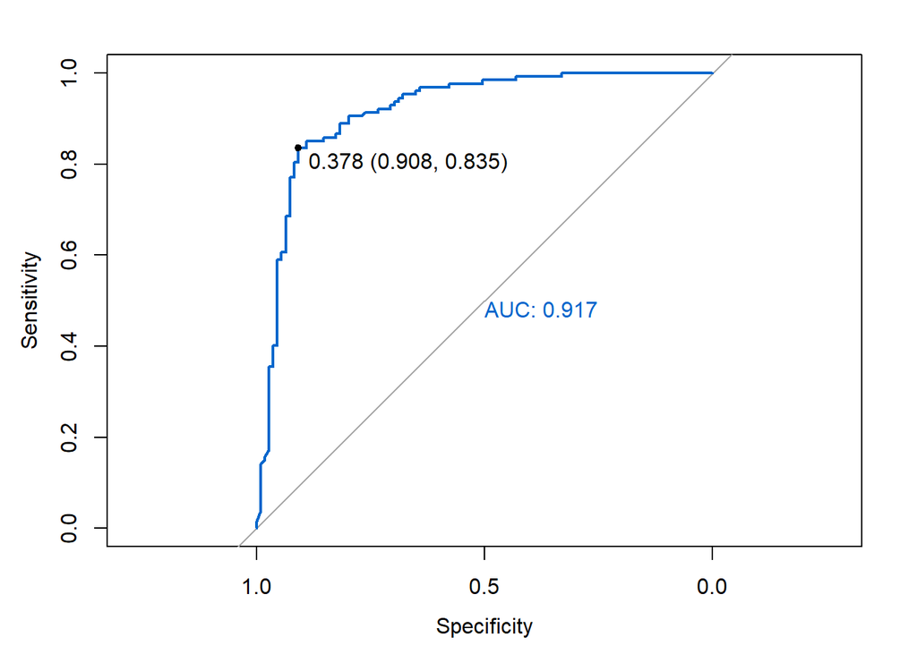

```r
resultat <- Valid_ROC(as.numeric(XY_test$HeartDisease)-1,as.numeric(rf1$test$votes[,1]), graph = T)
```

```r
resultat$roc
```

```
##                 roc
## AUC_lower 0.8792034
## AUC       0.9172506
## AUC_upper 0.9552978
## youden    0.7429026
```

- Evolution des spécificités, sensibilités et seuillage

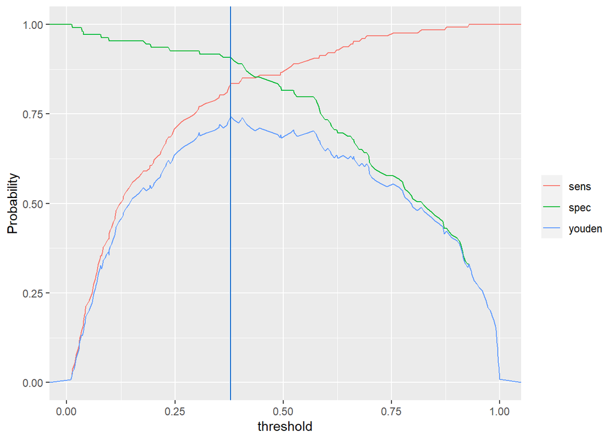

```r
resultat$graph
```

* Matrice des confusions avec seuillage définie par l’index de Youden

```r
resultat$result
```

```
##                 Confusion
## Accuracy       0.13135593
## AccuracyLower  0.09102477
## AccuracyUpper  0.18124087
## Sensitivity    0.09174312
## Specificity    0.16535433
## Pos Pred Value 0.08620690
## Neg Pred Value 0.17500000
## F1             0.08888889
## Threshold      0.37800000
```

```r
resultat$Confusion
```

```
##           Reference
## Prediction   0   1
##          0  10 106
##          1  99  21
```

##### 3.4 Prédiction - déploiement

Nous utilisons maintenant le jeux de données de déploiement (partition 2) pour vérifier la qualité de la prédiction

```r
pred_dep <- predict(rf1, X_dep, type = 'prob')
head(pred_dep ,10) %>% kbl() %>%  kable_styling( position = "center", full_width = FALSE)
```

|  | 0 | 1 |
| --- | --- | --- |
| 10 | 0.986 | 0.014 |
| 12 | 0.058 | 0.942 |
| 18 | 0.997 | 0.003 |
| 35 | 0.988 | 0.012 |
| 40 | 0.136 | 0.864 |
| 43 | 0.988 | 0.012 |
| 44 | 0.976 | 0.024 |
| 55 | 0.172 | 0.828 |
| 58 | 0.506 | 0.494 |
| 59 | 0.681 | 0.319 |

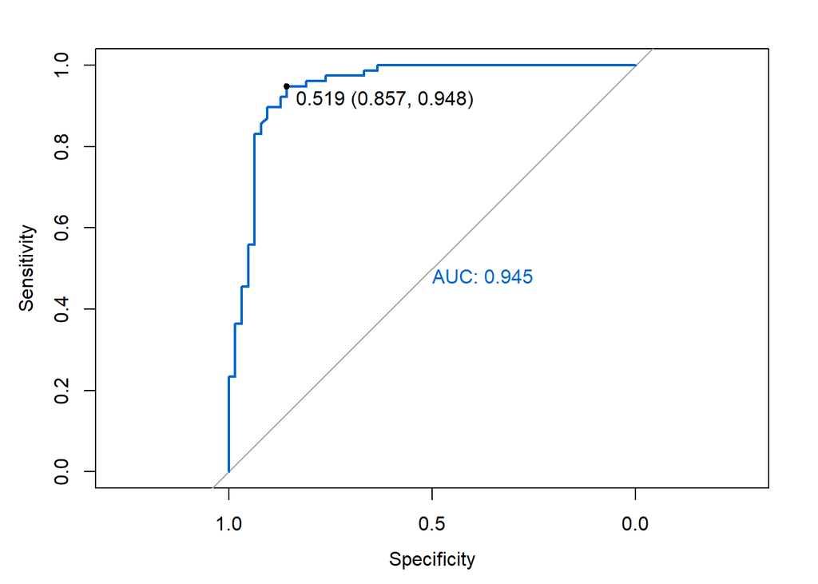

```r
resultat_pred <- Valid_ROC(as.numeric(XY_dep$HeartDisease)-1,as.numeric(pred_dep[,1]), graph = T)
```

```r
resultat_pred$roc
```

```
##                 roc
## AUC_lower 0.9056730
## AUC       0.9454752
## AUC_upper 0.9852773
## youden    0.8051948
```

- Evolution des spécificités, sensibilités et seuillage

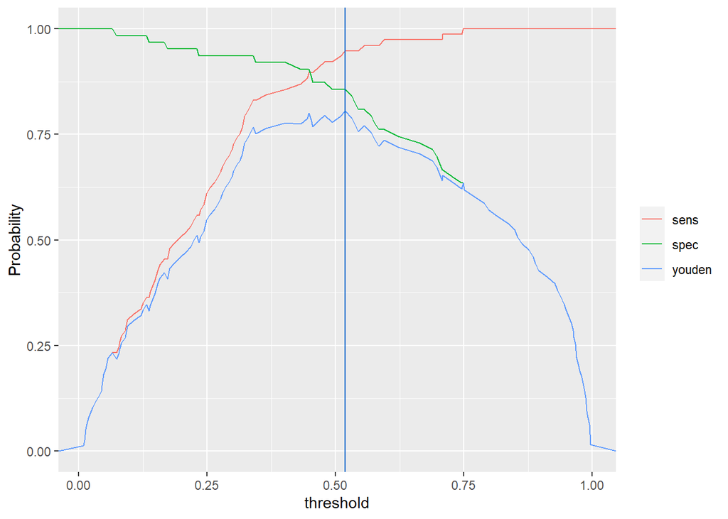

```r
resultat_pred$graph
```

* Matrice des confusions avec seuillage définie par l’index de Youden

```r
resultat_pred$result
```

```
##                 Confusion
## Accuracy       0.09285714
## AccuracyLower  0.05037346
## AccuracyUpper  0.15355377
## Sensitivity    0.14285714
## Specificity    0.05194805
## Pos Pred Value 0.10975610
## Neg Pred Value 0.06896552
## F1             0.12413793
## Threshold      0.51900000
```

```r
resultat_pred$Confusion
```

```
##           Reference
## Prediction  0  1
##          0  9 73
##          1 54  4
```

#### 4 Les aides graphiques

##### 4.1 Graphique de proximité

Une fonctionnalité intéressante est l’affichage des proximités issus de la prédiction réalisée par l’algorithme. Ce graphique est représenté en deux dimensions (obtenus par diminution de dimensionalité - méthode MDS). Chaque individu est représenté par un point du graphique de sorte que la ‘distance’ entre deux individus soit la plus proche possible. Ce graphique permet de repérer d’éventuels individus atypique et les regroupements d’individus par classe. Pour obtenir le graphique, il est nécessaire d’ajouter l’option proximity = T

- Le MDS, est une autre façon de représenter clairement l’information contenue dans une matrice de distances.
  - On utilise MDSplot (Multi-dimensional Scaling Plot of Proximity matrix from randomForest) pour tracer les coordonnées de mise à l’échelle de la forêt aléatoire rf1 dont nous disposons.

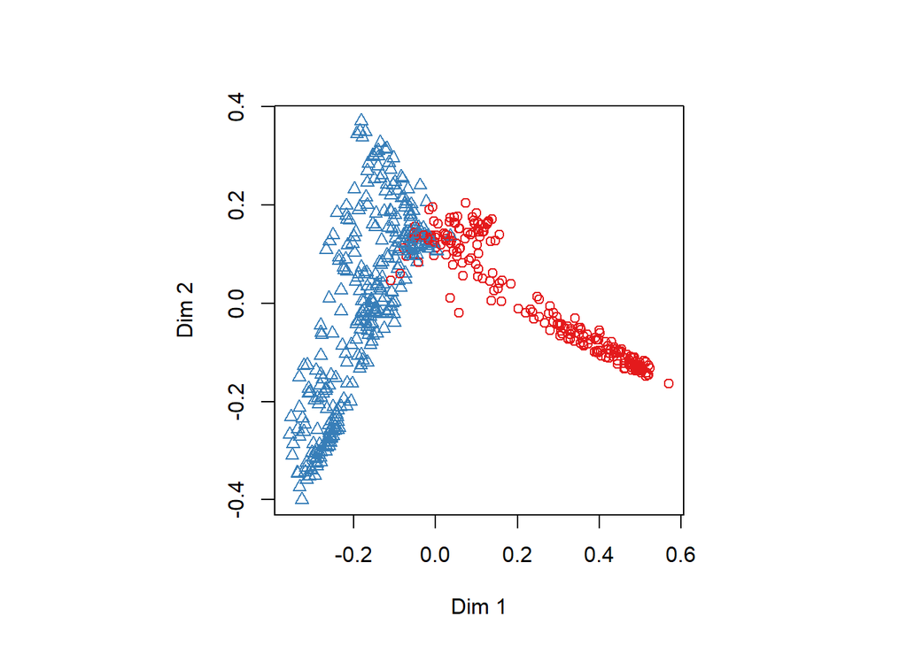

```r
MDSplot(rf1, rf1$predicted, k=2 ,pch=as.numeric(rf1$predicted))
```

Dans la figure précédente, On observe une forme en U inversée. Les couleurs (bleu- rouge) des points correspondent au classement effectué par l’algorithme. La position des individus (et de leurs distance entre eux) est obtenue à partir d’une diminution de dimension par analyse factorielle (analogue au projection ACP) Comme on peut le constater, la méthode des forêts aléatoires permet une bonne classification des individus même dans le cas des zones à risque (partie supérieure du graphique: forte proximité des points) ou des individus dans les deux branches.

##### 4.2 Importance des variables

Distribution de la profondeur des noeuds en fonction des variables

On veut afficher un diagramme en barres à barres cumulées :

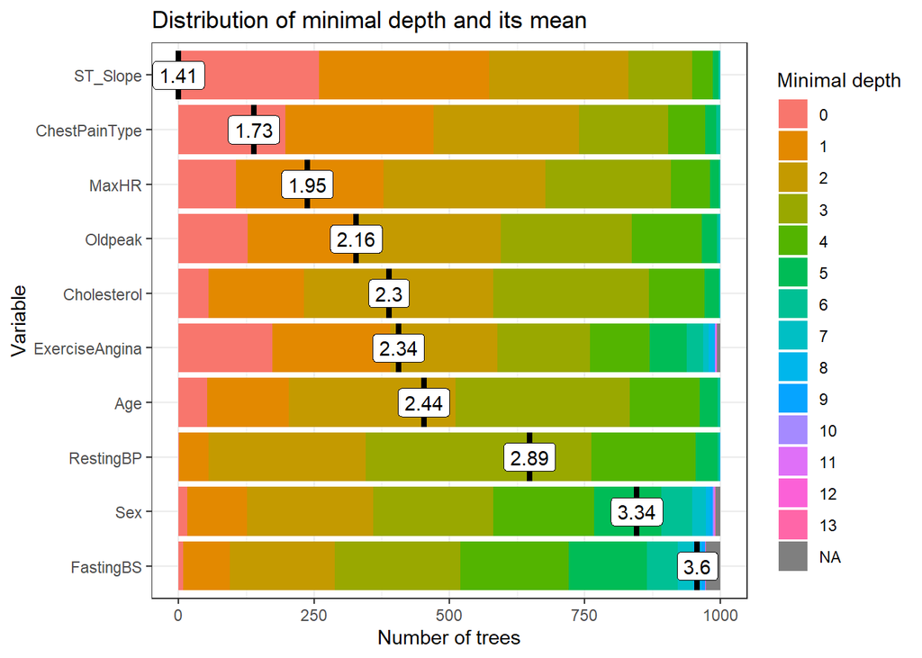

```r
md_frame <- min_depth_distribution(rf1)
plot_min_depth_distribution(md_frame, mean_sample = "top_trees") # default mean_sample arg
```

Importance des variables Mean Decrease Gini ou Mean Decrease Accuracy

- Il vaut mieux utiliser le critère Mean Decrease Accuracy car il est plus général. En effet, le critère “mean decrease Gini”” ne s’applique qu’à la construction des arbres CART. Le graphe suivant fournit l’importance des variables (en % da la totalité des importances de toutes les variables)

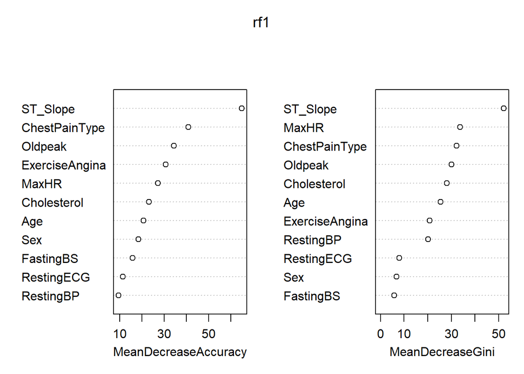

```r
varImpPlot(rf1)
```

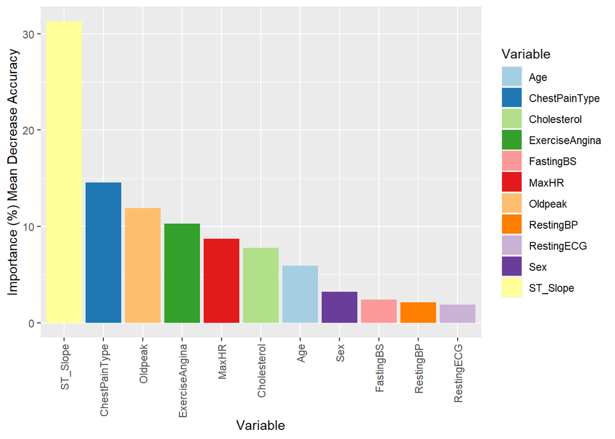

```r
# Création d'un data.frame avec les données
importance_df <- data.frame(
  Variable = row.names(rf1$importance),
  MeanDecreaseAccuracy = rf1$importance[,3],
  stringsAsFactors = FALSE
)

# Calcul de la somme totale de toutes les importances
total_importance <- sum(importance_df$MeanDecreaseAccuracy)
# Calcul des pourcentages de chaque variable
importance_df$Percentage <- importance_df$MeanDecreaseAccuracy / total_importance * 100
# Création du graphique en barres
ggplot(importance_df, aes(x = reorder(Variable, -Percentage), y = Percentage, fill = Variable)) +
  geom_bar(stat = "identity") +
  labs(x = "Variable", y = "Importance (%) Mean Decrease Accuracy") +
  theme(plot.title = element_text(hjust = 0.5),
        axis.text.x = element_text(angle = 90, vjust = 0.5, hjust=1)) +
  scale_fill_brewer(palette = "Paired")
```

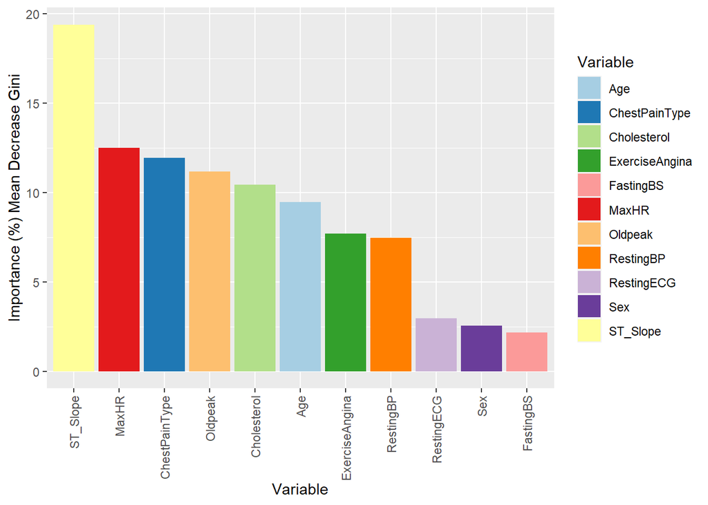

```r
# Création d'un data.frame avec les données
importance_df2 <- data.frame(
  Variable = row.names(rf1$importance),
  MeanDecreaseGini = rf1$importance[,4],
  stringsAsFactors = FALSE
)

# Calcul de la somme totale de toutes les importances
total_importance2 <- sum(importance_df2$MeanDecreaseGini)

# Calcul des pourcentages de chaque variable
importance_df2$Percentage <- importance_df2$MeanDecreaseGini / total_importance /10
# Création du graphique en barres
ggplot(importance_df2, aes(x = reorder(Variable, -Percentage), y = Percentage, fill = Variable)) +
  geom_bar(stat = "identity") +
  labs(x = "Variable", y = "Importance (%) Mean Decrease Gini") +
  theme(plot.title = element_text(hjust = 0.5),
        axis.text.x = element_text(angle = 90, vjust = 0.5, hjust=1)) +
  scale_fill_brewer(palette = "Paired")
```

#### 5 Selection des variables

```r
df2 <- read.table('heart.csv', header = T, sep = ',', dec = '.')
df2$HeartDisease = factor(df2$HeartDisease )
df2 <- data.frame(df2[,-c(2,4,6)])
set.seed(457867)
#--> Données de déploiement
id_dep2   <- createDataPartition(1:nrow(df2), p = 0.15, list = F)
XY_dep2   <- df2[id_dep2, ]   ; X_dep2 <- df2[  id_dep2, 1:8] ; Y_dep2 <- df2[  id_dep2,9]
#--> Données en entrainement et en test
XY2        <- df2[- id_dep2, ] ; X     <- df2[- id_dep2, 1:8] ; Y    <- df2[- id_dep2,9]
id_test2   <- createDataPartition(1:nrow(XY2), p = 0.3, list = F)
XY_test2   <- XY2[  id_test2, ] ; X_test2  <- XY2[  id_test2, 1:8] ; Y_test2  <- XY2[  id_test2,9]
XY_train2  <- XY2[- id_test2, ] ; X_train2 <- XY2[- id_test2, 1:8] ; Y_train2 <- XY2[- id_test2,9]
set.seed(547213)
n_tree2 = 1000
rf2 <- randomForest(HeartDisease~., data = XY_train2           ,
                    ntree       = n_tree2                      ,
                    mtry        = floor(sqrt(ncol(X_train)))  ,
                    nodesize    = 1                           ,
                    replace     = T                           ,
                    importance  = T                           ,
                    keep.forest = T                           ,
                    proximity   = T                           ,
                    na.action   = na.omit                     ,
                    xtest       = X_test2                      ,
                    ytest       = Y_test2                      ,
                   )
idx2 <- 1:nrow(XY_train2)
oob.time2 <- data.frame(Ind = paste0("ind_",idx)  ,OBB= rf2$oob.times)
head(oob.time2)
```

```
##     Ind OBB
## 1 ind_1 379
## 2 ind_2 359
## 3 ind_3 355
## 4 ind_4 367
## 5 ind_5 351
## 6 ind_6 355
```

```r
tx_erreur_train2 <- rf2$err.rate
tx_erreur_test2 <- rf2$test$err.rate
head(tx_erreur_train2)
```

```
##            OOB         0         1
## [1,] 0.2000000 0.2307692 0.1794872
## [2,] 0.2222222 0.2836879 0.1748634
## [3,] 0.2219388 0.2774566 0.1780822
## [4,] 0.1885965 0.2295918 0.1576923
## [5,] 0.2217573 0.2560386 0.1955720
## [6,] 0.2055888 0.2328767 0.1843972
```

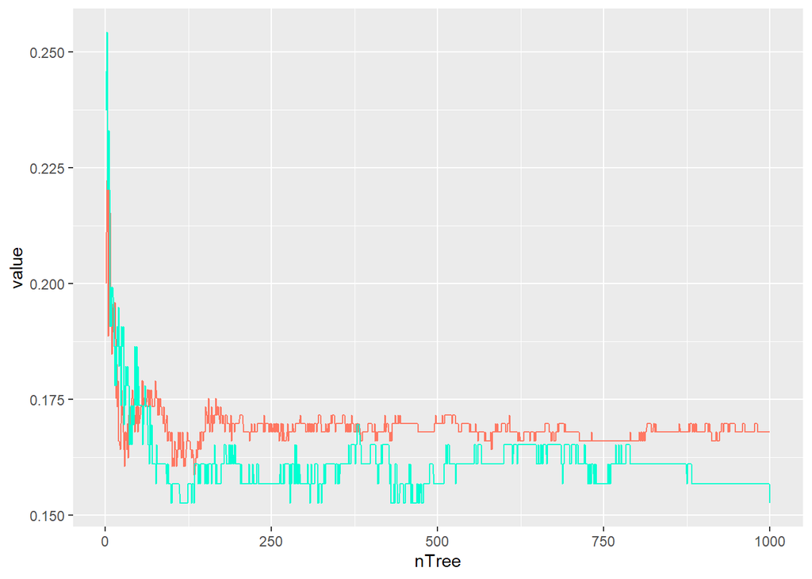

```r
OBB_train2 <- tx_erreur_train2[,1]
Test2 <- tx_erreur_test2[,1]
ntree2 <- 1:n_tree2
tab_visualisation2 <- data.frame(OBB_train2,Test2)
ggplot(tab_visualisation2, aes(x = ntree2)) + geom_line(aes(y= OBB_train2), color = "#FF7762") + geom_line(aes(y=Test2), color ="#00FFD1") + xlab("nTree") + ylab("value") + theme(legend.position = "right")
```

```r
head(rf2$test$votes,10)
```

```
##        0     1
## 3  0.942 0.058
## 9  0.214 0.786
## 11 1.000 0.000
## 13 1.000 0.000
## 15 0.996 0.004
## 20 0.607 0.393
## 26 0.999 0.001
## 31 0.493 0.507
## 32 0.958 0.042
## 34 0.241 0.759
```

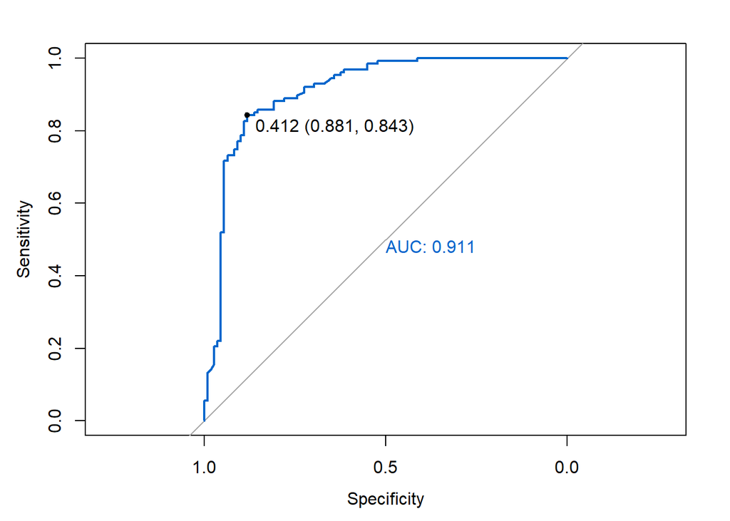

```r
resultat2 <- Valid_ROC(as.numeric(XY_test2$HeartDisease)-1,as.numeric(rf2$test$votes[,1]), graph = T)
```

```r
resultat2
```

```
## $result
##                 Confusion
## Accuracy       0.13983051
## AccuracyLower  0.09824724
## AccuracyUpper  0.19073409
## Sensitivity    0.11926606
## Specificity    0.15748031
## Pos Pred Value 0.10833333
## Neg Pred Value 0.17241379
## F1             0.11353712
## Threshold      0.41250000
##
## $Confusion
##           Reference
## Prediction   0   1
##          0  13 107
##          1  96  20
##
## $roc
##                 roc
## AUC_lower 0.8713460
## AUC       0.9111103
## AUC_upper 0.9508746
## youden    0.7232536
##
## $graph
```

[figure not shown]

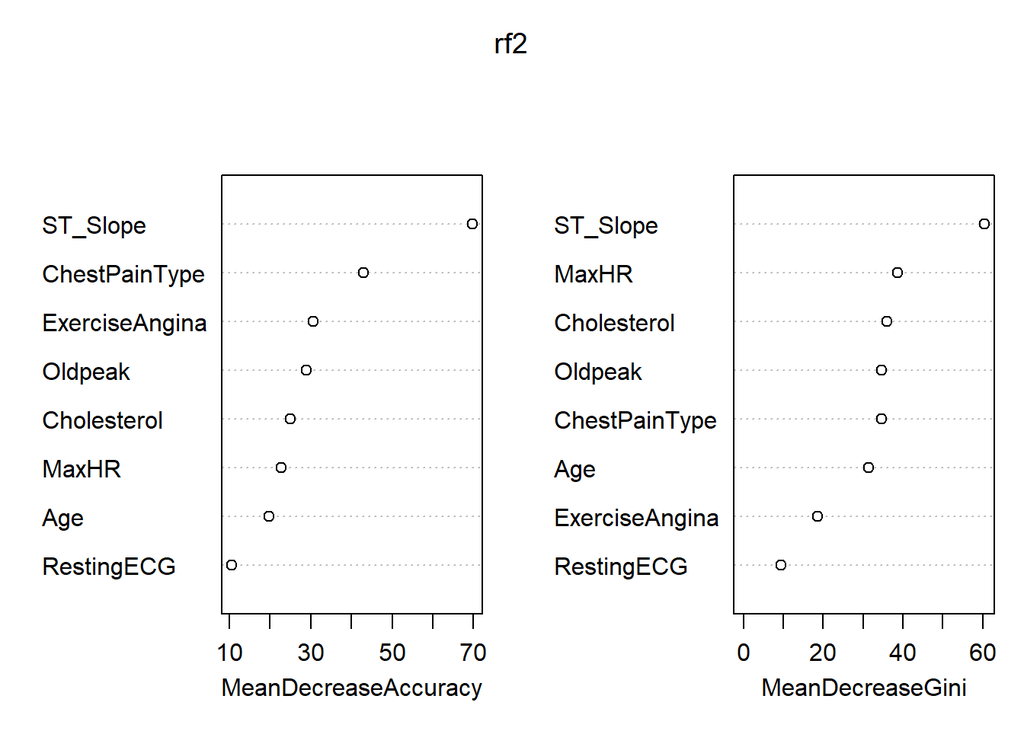

```r
#cmdscale(resultat_pred2$result)
#md_frame2 <- min_depth_distribution(rf2)
#plot_min_depth_distribution(md_frame2, mean_sample = "top_trees") # default mean_sample arg
varImpPlot(rf2)
```

```r
importance(rf2)
```

```
##                        0          1 MeanDecreaseAccuracy MeanDecreaseGini
## Age            21.007230  6.7009269             19.72235        31.367397
## ChestPainType  34.406226 30.5706404             42.99205        34.590122
## Cholesterol    26.261144  7.7486605             24.97912        36.039658
## RestingECG     15.109283 -0.1790639             10.45408         9.456621
## MaxHR           7.981908 20.8686497             22.68882        38.714629
## ExerciseAngina 15.693187 28.7505860             30.62268        18.612481
## Oldpeak        30.197272  8.3399054             28.98275        34.699874
## ST_Slope       64.255276 36.8873881             69.85903        60.557106
```

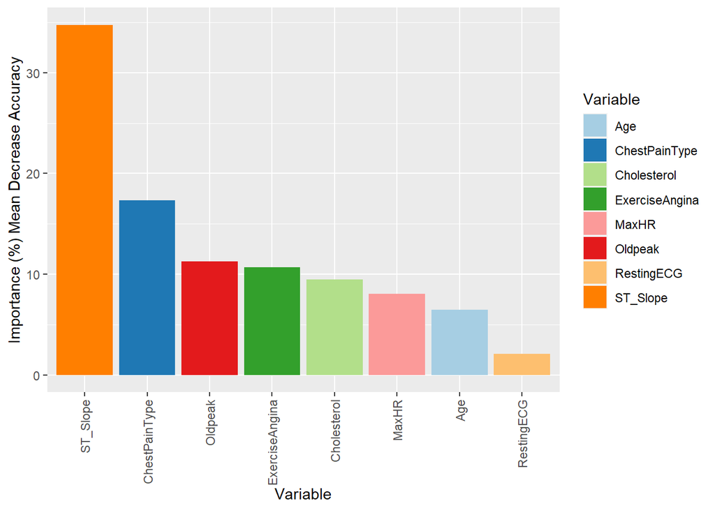

```r
##GRAPHIQUE MEAN 1
importance_df3 <- data.frame(
  Variable = row.names(rf2$importance),
  MeanDecreaseAccuracy = rf2$importance[,3],
  stringsAsFactors = FALSE
)

# Calcul de la somme totale de toutes les importances
total_importance3 <- sum(importance_df3$MeanDecreaseAccuracy)
# Calcul des pourcentages de chaque variable
importance_df3$Percentage <- importance_df3$MeanDecreaseAccuracy / total_importance3 * 100
# Création du graphique en barres
ggplot(importance_df3, aes(x = reorder(Variable, -Percentage), y = Percentage, fill = Variable)) +
  geom_bar(stat = "identity") +
  labs(x = "Variable", y = "Importance (%) Mean Decrease Accuracy") +
  theme(plot.title = element_text(hjust = 0.5),
        axis.text.x = element_text(angle = 90, vjust = 0.5, hjust=1)) +
  scale_fill_brewer(palette = "Paired")
```

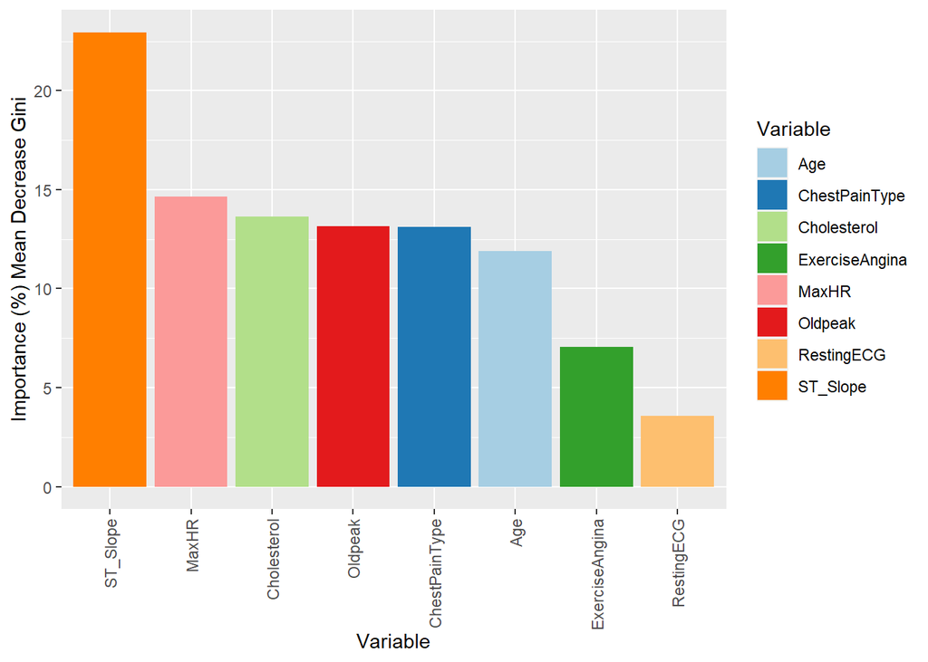

```r
##GRAPHIQUE MEAN 2

# Création d'un data.frame avec les données
importance_df4 <- data.frame(
  Variable = row.names(rf2$importance),
  MeanDecreaseGini = rf2$importance[,4],
  stringsAsFactors = FALSE
)

# Calcul de la somme totale de toutes les importances
total_importance4 <- sum(importance_df4$MeanDecreaseGini)

# Calcul des pourcentages de chaque variable
importance_df4$Percentage <- importance_df4$MeanDecreaseGini / total_importance4 *100
# Création du graphique en barres
ggplot(importance_df4, aes(x = reorder(Variable, -Percentage), y = Percentage, fill = Variable)) +
  geom_bar(stat = "identity") +
  labs(x = "Variable", y = "Importance (%) Mean Decrease Gini") +
  theme(plot.title = element_text(hjust = 0.5),
        axis.text.x = element_text(angle = 90, vjust = 0.5, hjust=1)) +
  scale_fill_brewer(palette = "Paired")
```